# CatRank sketch

DA Auerbach

May 10, 2017

# Boundary extent polygons

Obviously King County has more detailed and locally informed datasets, but for the sake of quick demonstration we can start with just a few polygon(s) to constrain the national data. The following chunk pulls together “basin” and “watershed” polygons from the King GIS ftp along with the basic political boundaries using GADM from `raster::getData`.

```r
uz <- "ftp://ftp.kingcounty.gov/gis-web/GISData/hydroGDB.zip"
fnuz <- basename(uz)
dirzip <- tempdir()
setwd(dirzip)
if(!file.exists(fnuz)){
    download.file(uz, destfile=fnuz, quiet = F
                  ,mode=ifelse(Sys.info()["sysname"]=="Windows","wb","w"))
  }
unzip(fnuz, exdir = "/Users/dauerbac/Documents/R")
setwd("/Users/dauerbac/Documents/R/hydroGDB/")

rgdal::ogrListLayers("KingCounty_GDB_hydro.gdb")
#these are lambert, feet
bsn <- rgdal::readOGR("KingCounty_GDB_hydro.gdb"
                      ,layer="topo_basin_kc_area"
                      ,stringsAsFactors=F)
wtr <- rgdal::readOGR("KingCounty_GDB_hydro.gdb"
                      ,layer="topo_watershed_kc_area"
                      ,stringsAsFactors=F)

#this is longlat WGS84
cnty <- raster::getData("GADM", country="USA", level=2)
i <- cnty@data %>%
  filter(NAME_1 == "Washington", NAME_2 == "King") %>% .$OBJECTID
king <- cnty[cnty$OBJECTID == i,]
```

# Subset NHDPlus

Next we can intersect these polygons with the [NHDPlus](http://www.horizon-systems.com/NHDPlus/NHDPlusV2_home.php) dataset, a heavily refined and extended version of the “medium-resolution” NHD (sometimes called 1:100,000) with fairly extensive documentation. Here I’m using (lightly) simplified catchments for Washington state that I have handy, but this can be modified fairly simply to flowlines etc.

```r
#57314 simplified catchments in AEA, NAD83, m; ~226mb in mem
waCat <- readOGR("/Users/dauerbac/Documents/R/NHDstates", "_WA", stringsAsFactors = F)
#reproject extent objects
king <- spTransform(king, waCat@proj4string)
wtr <- spTransform(wtr, waCat@proj4string)
bsn <- spTransform(bsn, waCat@proj4string)
#perform the intersect/over on the single feature king object
#(choice not critical here, effectively identical extent)
kcat <- waCat[king,c("FEATUREID")]
kcat@data <- kcat@data %>% rename(COMID = FEATUREID)
##not run here, but can do a quick base plot to make sure things are as expected
par(mar=rep(0,4))
plot(king, border=4, lwd=3) #1 political extent
plot(wtr, add=T, border=3, lwd=2) #11 watersheds
plot(bsn, add=T, border=1) #100 basins
plot(kcat, add=T, border="tan", lwd=0.2) #2351 catchments
```

# Join streamCat & monthly EROM

Now for a more interesting part: associate the StreamCat landscape attributes by joining from a national geopackage.

```r
#src_sqlite(f) #lists the tbls
f <- "/Users/dauerbac/Documents/R/streamcat.gpkg"
#506 attributes/features/variables
s <- src_sqlite(f) %>% tbl(.,"streamcat")
kcat@data <- s %>%
  filter(COMID %in% kcat$COMID) %>% #just the rows in King Country
  select(COMID:NHDPlus_Region) %>% #starting with all features
  collect(n = Inf) %>% #bring into memory from disk
  left_join(kcat@data, ., by="COMID") #this is nicely one to one (not gauranteed from the %in% filter)
```

We can add the NHDPlus estimates of streamflow (discharge, Q) the same way to arrive at a 2351 x 527 spatial polygon dataframe.

```r
f <- "/Users/dauerbac/Documents/R/NHDPlus_Seamless_0403.gpkg"
s <- src_sqlite(f) %>% tbl(.,"NHDFlowline_Network")
kcat@data <- s %>%
  filter(COMID %in% kcat$COMID) %>% #again just King Country
  select(VPUID, REACHCODE, COMID, FCODE
         ,StreamOrde, LENGTHKM, ArbolateSu, TotDASqKM, MINELEVSMO, MAXELEVSMO, SLOPE
         ,contains("QE_")) %>%
  collect(n = Inf) %>%
  left_join(kcat@data, ., by="COMID")
#save this out
saveRDS(kcat, "/Users/dauerbac/Google Drive/NHDplus/kingCo_StrcatEROM_spdf.rds")
```

# Simple prioritization

Of course we’d want to explore these data **much** more, and the following decisions are best made if vetted with stakeholder input, but as a starting point we can make several choices to focus a demonstration analysis.

First, we can emphasize the features that are calculated for a 100m ripirian buffer per flowline associated with each catchment. Like the non-riparian versions, these come in 2 flavors: the local catchment (“cat”) and the entire upstream watershed (“Ws”; calc’d as the arithmetic mean, see the StreamCat documentation). Both could be appropriate and informative, but an initial focus on the “cat” makes a (greatly) simplifying assumption that nearby conditions in the local catchment take priority.

Next, we can examine features that are presumptively stressors or sources of aquatic ecosystem uplift (or both). This is a much-considered question in the literature, along with the appropriate technical and conceptual approaches to weighting the focal set. Complementing the StreamCat data and EPA efforts to examine overall “integrity”, the [NFHP](https://ecosystems.usgs.gov/fishhabitat/) project has generated relevant datasets and analyses, with both building from conceptual foundations developed in the ongoing Recovery Potential Screening tools and data [RPS](https://www.epa.gov/rps/rps-methodology-using-rps-tool-compare-watersheds-and-evaluate-options) + [WSIO](https://www.epa.gov/wsio/data-tables-and-map-services). In any event, a few putative stressors could be used to screen for higher or lower restoration priorities (depending on goals and budget) and/or areas perhaps more suited to protection if lower riparian stressor incidence is assumed to correspond to better in-stream conditions (which is reasonable but may not necessarily be the case).

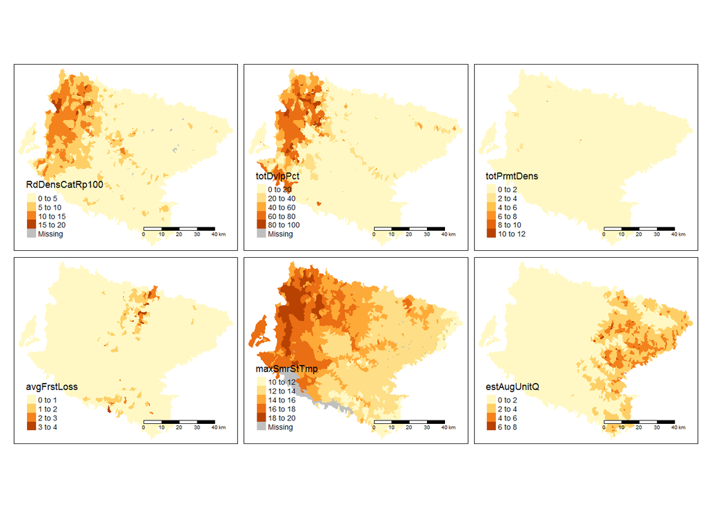

```r
kc <- kcat #make a copy to preserve the base object
kc@data <- kc@data %>%
  mutate(totDvlpPct = PctUrbHi2011CatRp100 + PctUrbMd2011CatRp100 + PctUrbLo2011CatRp100
         ,totPrmtDens = NPDESDensCat + SuperfundDensCat + TRIDensCat
         ,avgFrstLoss = rowMeans(dplyr::select(kcat@data, contains("PctFrstLoss")), na.rm=T)
         ,maxSmrStTmp = apply(dplyr::select(kcat@data, contains("MSST_")),1,max)
         ,estAugUnitQ = QE_09 / TotDASqKM #for all months+annual: mutate_at(vars(contains("QE_")), funs(./TotDASqKM))
         ) %>%
  select(RdDensCatRp100, totDvlpPct, totPrmtDens
         ,avgFrstLoss, maxSmrStTmp, estAugUnitQ)

#these features can be quickly visualized
tm_shape(kc) + tm_fill(col = names(kc)) +
  tm_scale_bar(position = c("right","bottom"))
```

```r
#making apparent the highly skewed distributions in "total developed" and "total permit density"
sapply(kc@data, quantile, na.rm = T)
```

```
##      RdDensCatRp100 totDvlpPct totPrmtDens avgFrstLoss maxSmrStTmp
## 0%        0.0000000    0.00000     0.00000 0.000000000    10.63288
## 25%       0.8076638    0.00000     0.00000 0.006177438    12.82854
## 50%       2.6357002    0.00000     0.00000 0.048083229    13.56586
## 75%       4.3744726    5.51599     0.00000 0.209199703    15.38561
## 100%     18.4851622  100.00000    10.38422 3.661213990    19.51689
##      estAugUnitQ
## 0%     0.0000000
## 25%    0.1754029
## 50%    0.9737393
## 75%    2.9288147
## 100%   7.9123069
```

```r
#a coarse option is to just set fixed thresholds:
#is total dvlp percentage < 10%? is permit density == 0?

#this could be written as a more flexible user function
#but the following shows a basic "hardcoded" option
kc@data <- kc@data %>%
  mutate_at(vars(RdDensCatRp100,avgFrstLoss, maxSmrStTmp, estAugUnitQ)
             ,funs(findInterval(., quantile(., na.rm=T)))) %>%
  mutate(target = (RdDensCatRp100==1) & #below 25th in riparian road density
           (avgFrstLoss==1) & #below 25th in forest loss 2008-2013
           (maxSmrStTmp==1) & #coolest quartile estimated summer stream temp
           (estAugUnitQ==4) & #greatest estimated mean Aug. streamflow
           (totDvlpPct <10) & #less than 10% low+medium+high developed cover
           (totPrmtDens<1) #low total density of NPDES, Superfund & TRI
           )

#these conditions highlight 93 of the 2351 catchments, roughly 4%
sum(kc$target, na.rm = T); sum(kc$target/nrow(kc), na.rm = T)
```

```
## [1] 93
```

```
## [1] 0.03955764
```

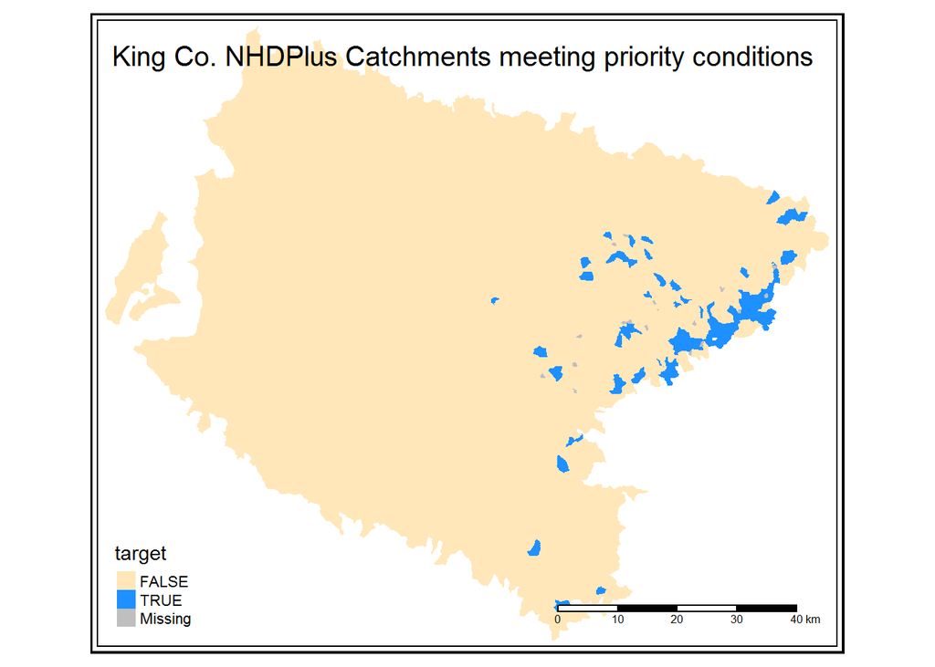

```r
#and the targets are, unsurprisingly, higher toward the mountains
tm_shape(kc) + tm_fill(col = "target", palette = c("wheat1","dodgerblue")) +
  tm_scale_bar(position = c("right","bottom")) +
  tm_layout(title = "King Co. NHDPlus Catchments meeting priority conditions", frame.double.line = T, legend.outside = F)
```